# Usage Patterns of Bay Wheels Bicycle Sharing System

## Moamen Abdelkawy

## Investigation Overview

This investigation studies the differences in usage patterns between customers and subscribers of Bay Wheels; and the main factors that affect the duration of the trip.

Bay Wheels (formerly Ford GoBike) is a regional public bicycle sharing system in California's San Francisco Bay Area, and one of the largest in the US. This investigation explores a dataset containing Bay Wheels's trip data during the period from $28^{th}$ June 2017 to $1^{st}$ April 2020.

## Dataset Overview

There are more than 5,000,000 trips in the dataset with 8 features:

- Trip duration (minutes)
- Distance between start and end station (km)
- Trip start time
- Trip end time
- Is it a weekend?
- User type (subscriber or customer)
- Start station name
- End station name

# Usage Trends and Patterns

## User Groups

Bay Wheels differentiate between two user groups; "Subscribers" who are members of an annual or a monthly plan, and "Customers" who pay for each single trip. During the investigation period, 78.4% of users were "Subscribers", while 21.6% were "Customers".

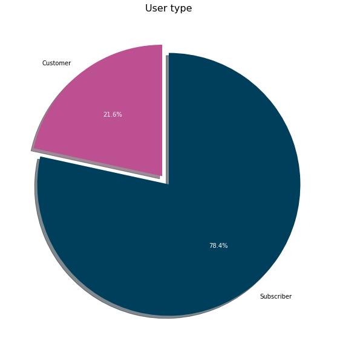

## Growth in Monthly Demand

The number of monthly trips is affected heavily by the season; after taking that into consideration, there is a clear growth in monthly trips until the last quarter of 2019.

For the most part, changes in monthly trips count tended to be similar for both user groups; this pattern persists till November 2019; after that, the number of "Customers" became, higher than this of "Subscribers".

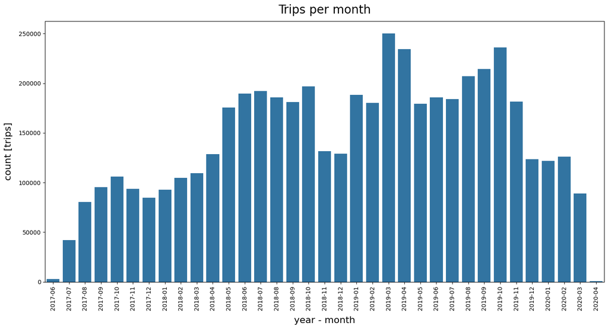

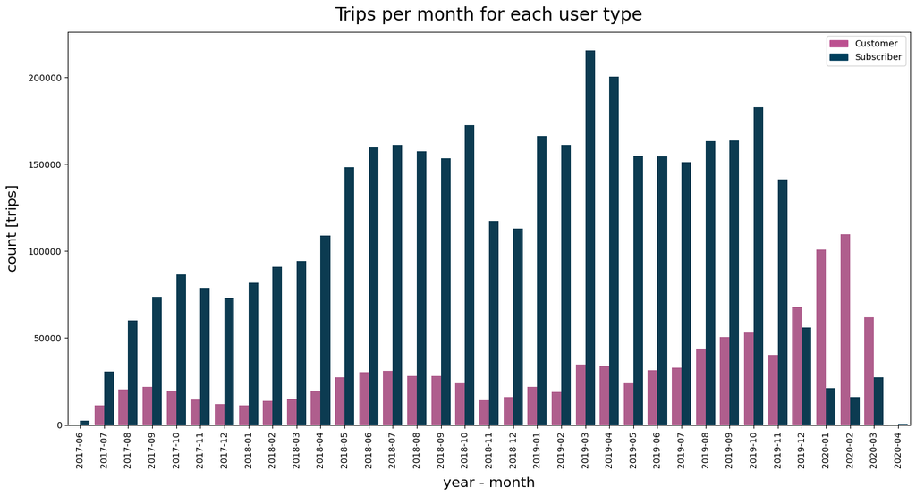

## Demand Fluctuations

Investigating demand during the month reveals that; daily demand of "Customers" tended to be more volatile compared to "Subscribers"; and that peaks and off-peak days are different for the two groups.

Weekends saw a significant drop in "Subscribers" demand, while "Customers" demand was smoother across the week.

On an hourly basis, both user groups have the same peak and off-peak hours; but "Subscribers" demand was more volatile.

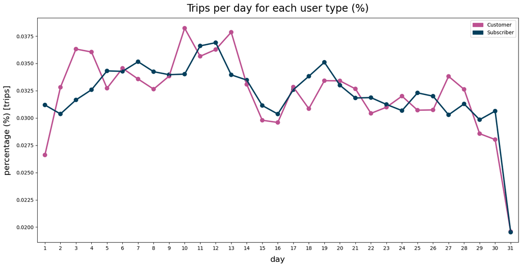

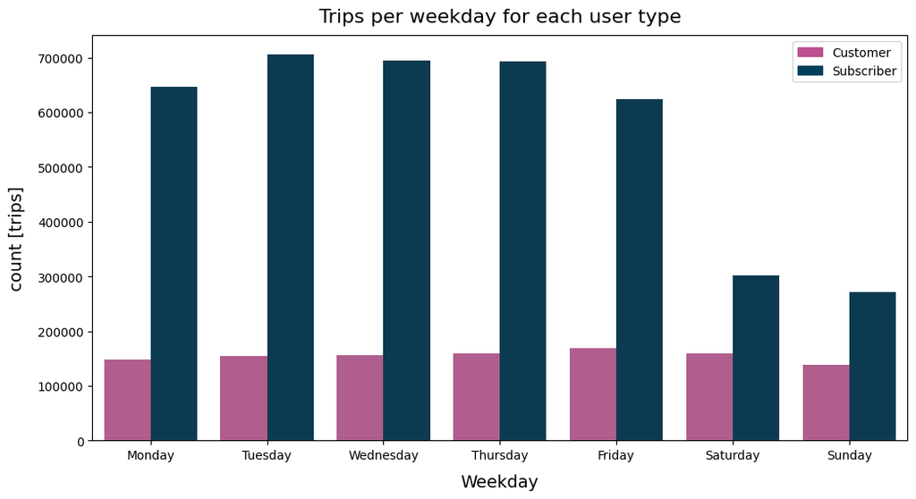

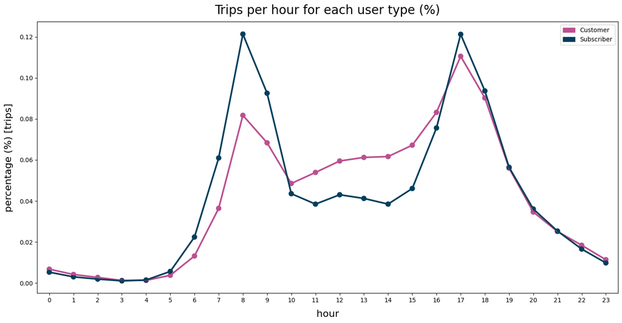

# Determinants of Trip Duration

## Distribution of Trip Durations

Trip durations in the dataset ranges from $1\:minute\:to\:about\:90\:minutes$. The distribution is right-skewed on a linear scale but when plotted on a logarithmic scale, the distribution of trip durations gets closer to normal but with a rough shape.

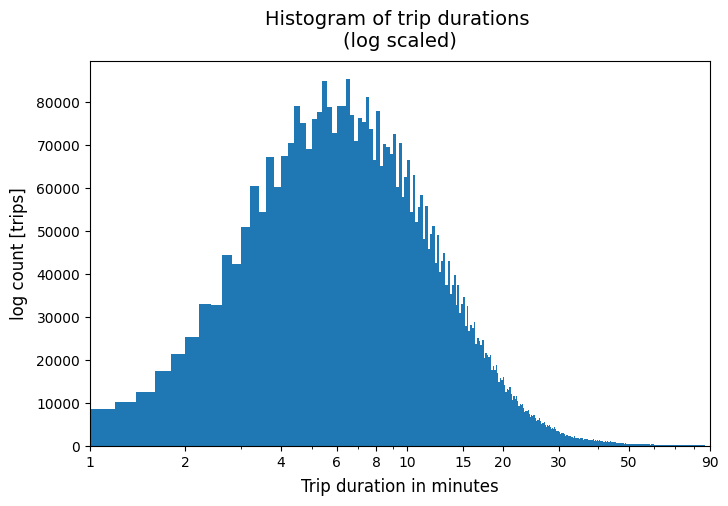

## Distribution of Distances between Start and End Stations

Distances between start and end station for each trip ranges from $0\:km\:to\:about\:5\:km$ in the dataset. The distribution is right-skewed on a linear scale; and when plotted on a symmetrical logarithmic scale, the distribution takes on a multimodal shape with a major mode at $1.3\:km$ and many minor modes.

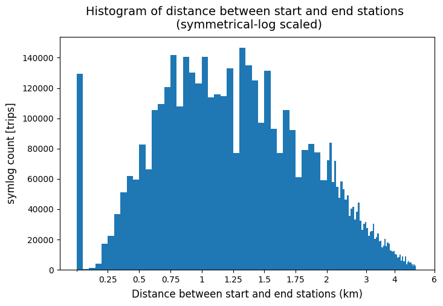

## Trip Duration vs. Distance between Start and End Stations

For short trips (duration less than 30 minutes), there is a strong linear correlation between duration and distance between start and end stations. This means that for short trips, it is likely that the bike will end the trip in a different station. This insight is important to keep stations stocked with enough bikes.

The linear correlation between duration and distance is stronger for "Subscribers", since duration values are more scattered for each distance in the case of "Customers".

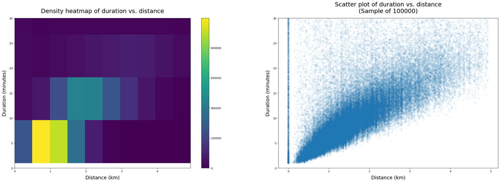

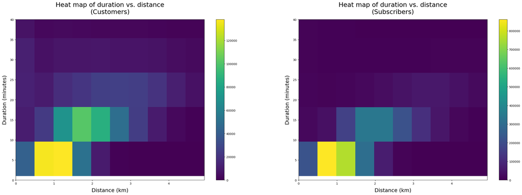

## Trip Duration and User Groups Usage Through the Week

"Customers" tend to have more duration for their trips, and their distribution also have more spread compared to "Subscribers". This means that "Customers" tend to vary their trip durations, while "Subscribers" typically use the service for short trips.

On weekends, bike trips tend to be longer, and the distribution of durations tends to have more spread on compared to workdays; this is more apparent for "Customers" but is true for both groups.

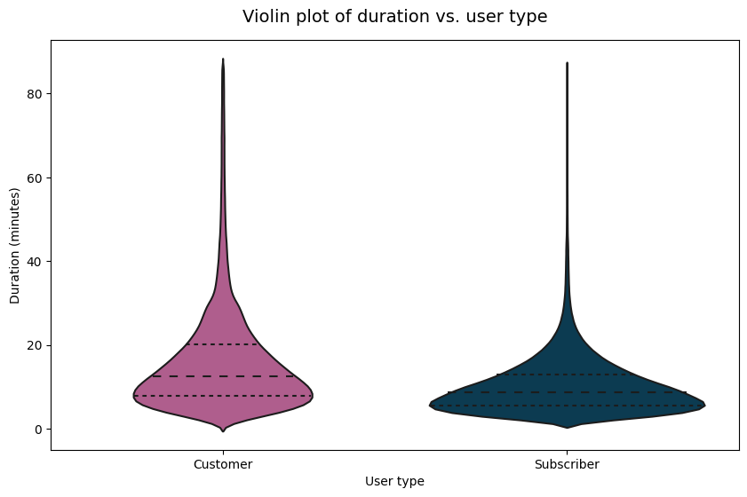

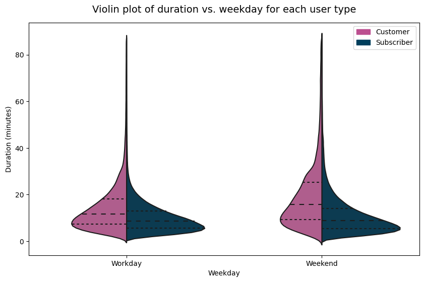